# biomass, cell area, rgnd models etc

```r
library(tidyverse)
library(here)
library(janitor)
library(MuMIn) # automated AIC model selection
library(GGally) # pretty pairs plots
library(gridExtra) # for multipanel figs
library(broom) # clean up model results
library(kableExtra) # tables
library(tidymodels)
```

# read in data

```r
biomass <- read_csv(here("data/biomass/tidy_biomass.csv"))
cellcount <- read_csv(here("data/cellcount/final_cell.csv"))
# convolved sample scans
as_s2 <- read_csv(here("data/radiometer/as_s2.csv"))
as_l8 <- read_csv(here("data/radiometer/as_l8.csv"))
as_terra <- read_csv(here("data/radiometer/as_terra.csv"))
as_planet <- read_csv(here("data/radiometer/as_planet.csv"))
as_albedo <- read_csv(here("data/radiometer/as_bb_albedo.csv"))
```

# Compute band indices

Based on the plot of the raw scans (see convolve_sample_scans script), the radio of red green, and red infrared appear proportional to algae abundance. Normalizing allows for comparability between images of different light intensity, since the ratio is all that matters. RGND was used by Ganey et al, and NDVI is a classic proxy for chlorophyll.

Given the data, feature engineering or multivariate regression to minimize the error is probably not worth it because the measurements have high error and our data is small.

```r
nd <- function(a,b){ (a-b)/(a+b) } # normalized difference function

compute_nds <- function(data, blue, green, red, nir, swir){
  blue <- enquo(blue)
  green <- enquo(green)
  red <- enquo(red)
  nir <- enquo(nir)
  swir <- enquo(swir)

  data %>%
    mutate(ndvi = nd(!!nir, !!red),
           rgnd = nd(!!red, !!green),
           gbnd = nd(!!green, !!blue),
           rbnd = nd(!!red, !!blue),
           ndsi = nd(!!red, !!swir)) %>%
    select(scan_id, sample_id, ndvi, rgnd, gbnd, ndsi)
}

as_s2_nd <- as_s2 %>% compute_nds(blue = b2, green = b3, red = b4, nir = b8, swir = b11)
as_l8_nd <- as_l8 %>% compute_nds(blue = band_2, green = band_3, red = band_4, nir = band_5, swir = band_6)
as_terra_nd <- as_terra %>% compute_nds(blue = RSR_469, green = RSR_555, red = RSR_645, nir = RSR_859, swir = RSR_1640)
```

## Cross-platform comparison

[output not shown]

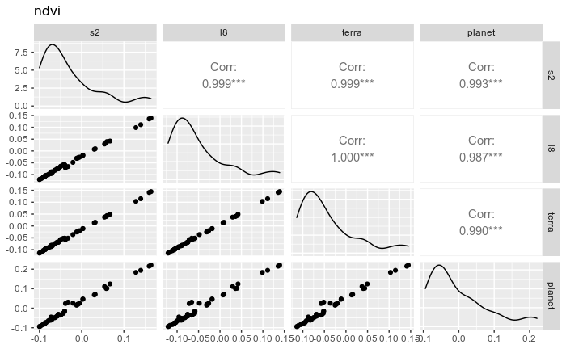

```r
sat_indices %>% my_pairs(ind = "ndvi")
```

Don’t consider GBND

| scan_id | sample_id | index | s2 | l8 | terra |
| --- | --- | --- | --- | --- | --- |
| 20210805_00100 | bdw21.02 | ndvi | 0.0030180953 | -0.018452474 | -0.0111289172 |
| 20210805_00100 | bdw21.02 | rgnd | 0.2142613276 | 0.202782642 | 0.2320741439 |
| 20210805_00100 | bdw21.02 | ndsi | 0.9506482690 | 0.949351288 | 0.9427240825 |
| 20210805_00101 | bdw21.02 | ndvi | 0.0027353157 | -0.018398286 | -0.0111961237 |
| 20210805_00101 | bdw21.02 | rgnd | 0.2132347281 | 0.201791304 | 0.2307809642 |
| 20210805_00101 | bdw21.02 | ndsi | 0.9526777661 | 0.951375180 | 0.9452820006 |
| 20210805_00102 | bdw21.03 | ndvi | 0.0541990234 | 0.029526416 | 0.0372189891 |
| 20210805_00102 | bdw21.03 | rgnd | 0.3123010519 | 0.297579702 | 0.3347386388 |
| 20210805_00102 | bdw21.03 | ndsi | 0.9411748388 | 0.939949449 | 0.9327140460 |
| 20210805_00103 | bdw21.03 | ndvi | 0.0671221482 | 0.042007396 | 0.0494033250 |

[output cut: 137 more lines]

## Compute mean (and sd) for each scan pair

```r
nd_sd <- indices2 %>%
  select(-scan_id) %>%
  group_by(sample_id, index) %>%
  summarise(across(everything(), list(mean = mean, sd = sd), .names = "{.col}_{.fn}")) %>%
  ungroup()
```

### cross-platform comparison of just mean vals

```r
nd_sd %>% select(index, contains("mean")) %>% my_pairs("ndvi")
nd_sd %>% select(index, contains("mean")) %>% my_pairs("rgnd")
nd_sd %>% select(index, contains("mean")) %>% my_pairs("ndsi")
```

[output not shown]

```r
nd_sd %>%
  filter(index=="ndvi") %>%
  select(sample_id, l8_mean, planet_mean) %>%
  mutate(dif = abs(l8_mean - planet_mean)) %>%
  arrange(-dif) %>%
  left_join(cellcount %>% group_by(sample_id) %>% summarise(frac_red = mean(frac_red)))
```

[output not shown]

Aside from perhaps a small caveat for Planet NDVI, Having shown that these satellite platforms will have the same index values I will now arbitrarily choose one platform (S2) for the remaining analysis.

| sample_id | mean_ndsi | mean_ndvi | mean_rgnd | sd_ndsi | sd_ndvi | sd_rgnd |
| --- | --- | --- | --- | --- | --- | --- |
| bdw21.02 | 0.9516630 | 0.002876706 | 0.2137480278 | 1.435071e-03 | 1.999554e-04 | 7.259154e-04 |
| bdw21.03 | 0.9396807 | 0.060660586 | 0.3167546499 | 2.113056e-03 | 9.138029e-03 | 6.298339e-03 |
| bdw21.04 | 0.8961082 | 0.162067678 | 0.3681139085 | 3.000898e-03 | 3.106340e-03 | 7.807401e-03 |
| bdw21.06 | 0.9575951 | -0.055334987 | 0.0832148903 | 4.607702e-04 | 4.435156e-04 | 2.278552e-03 |
| bdw21.07 | 0.9628722 | -0.095412837 | -0.0069161180 | NA | NA | NA |
| bdw21.08 | 0.9590142 | -0.063677348 | 0.0330774914 | 1.237724e-03 | 8.393472e-04 | 1.607869e-03 |
| bdw21.09 | 0.9534352 | -0.086630686 | 0.0005765586 | 3.984459e-04 | 2.335734e-04 | 3.735826e-04 |
| bdw21.10 | 0.9686366 | -0.090792521 | -0.0098094750 | 1.773080e-04 | 1.375078e-04 | 1.636195e-04 |
| tri21.03 | 0.9228237 | 0.134128522 | 0.3858625111 | 2.981640e-03 | 8.061609e-03 | 3.685110e-03 |
| tri21.04 | 0.9546112 | -0.040348874 | 0.0952351324 | 1.145976e-04 | 1.442086e-05 | 1.195810e-03 |

[output cut: 16 more lines]

## QC for duplicate scans discrepancies in indices

(this should already be take care of in the convolve script, but this is index specific)

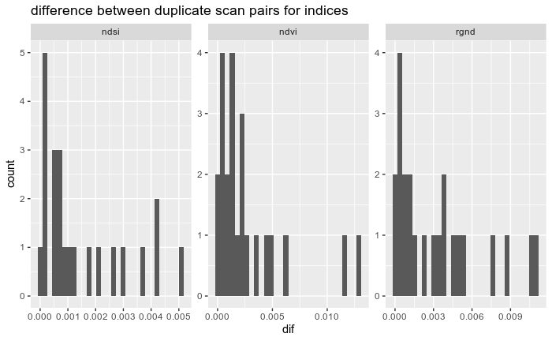

```r
dup_difs %>%
  ggplot(aes(dif)) +
  geom_histogram() +
  facet_wrap(vars(index), scales = "free") +
  ggtitle("difference between duplicate scan pairs for indices")
```

These differences are pretty low on a scale from -1 to 1

Compute the range of values for each index, to express the difference as a percent of the spread of values

| index | max | min | range |
| --- | --- | --- | --- |
| ndsi | 0.9761663 | 0.89398621 | 0.08218005 |
| ndvi | 0.1642642 | -0.10005418 | 0.26431837 |
| rgnd | 0.3884683 | -0.02071932 | 0.40918760 |

```r
dup_difs %>%
  left_join(ranges) %>%
  mutate(percent_dif = dif/range) %>%
  arrange(-percent_dif)
```

| sample_id | index | dif | range | percent_dif |
| --- | --- | --- | --- | --- |
| tri21.14 | ndsi | 5.164309e-03 | 0.08218005 | 6.284140e-02 |
| bdw21.04 | ndsi | 4.243911e-03 | 0.08218005 | 5.164162e-02 |
| tri21.03 | ndsi | 4.216676e-03 | 0.08218005 | 5.131021e-02 |
| bdw21.03 | ndvi | 1.292312e-02 | 0.26431837 | 4.889227e-02 |
| tri21.06 | ndsi | 3.620694e-03 | 0.08218005 | 4.405807e-02 |
| tri21.03 | ndvi | 1.140084e-02 | 0.26431837 | 4.313297e-02 |
| bdw21.03 | ndsi | 2.988313e-03 | 0.08218005 | 3.636299e-02 |
| whi21.04 | ndsi | 2.659890e-03 | 0.08218005 | 3.236661e-02 |
| bdw21.04 | rgnd | 1.104133e-02 | 0.40918760 | 2.698355e-02 |
| tri21.12 | rgnd | 1.067953e-02 | 0.40918760 | 2.609934e-02 |

[output cut: 59 more lines]

The NDSI comparisons are off a high percent because the range is so low to begin with. All NDVI is off <5%, and all RGND <3%. Data is ok to use.

# Join band data with cell abundance data

compute mean and SD for cell abundance data

| sample_id | frac_red_mean | frac_red_sd | inorg_carbon_mg | org_carbon_mg | nitrogen_mg | cell_cm2_per_l_mean | cell_cm2_per_l_sd | cells_in_sample_mean | cells_in_sample_sd |
| --- | --- | --- | --- | --- | --- | --- | --- | --- | --- |
| bdw21.02 | 0.21237238 | 0.005486303 | 0.001891898 | 15.2955278 | 0.33435749 | 1.3343750 | 0.03447146 | 7500000 | 2651650.4 |
| bdw21.03 | 0.47956567 | 0.005671993 | 0.006599183 | 38.6383538 | 0.80927205 | 4.7081250 | 0.05568466 | 7900000 | 424264.1 |
| bdw21.04 | 1.39599496 | 0.017059869 | 0.007252127 | 81.1355609 | 1.76602506 | 11.7893750 | 0.14407301 | 25923750 | 2466034.9 |
| bdw21.07 | 0.00000000 | 0.000000000 | NA | 1.1392013 | 0.05697854 | 0.0000000 | 0.00000000 | 0 | 0.0 |
| bdw21.08 | 0.06202348 | 0.075226676 | 0.007433395 | 8.9043610 | 0.42886063 | 0.5940625 | 0.72052308 | 666250 | 736765.2 |
| bdw21.09 | 0.00000000 | 0.000000000 | 0.006313118 | 15.3732653 | 0.93800518 | 0.0000000 | 0.00000000 | 0 | 0.0 |
| bdw21.10 | 0.00000000 | 0.000000000 | NA | 0.6500763 | 0.04593480 | 0.0000000 | 0.00000000 | 0 | 0.0 |
| tri21.03 | 0.69943027 | 0.228796838 | 0.017313734 | 32.7075965 | 1.02493748 | 4.2256250 | 1.38228167 | 25837500 | 6736730.8 |
| tri21.04 | 0.08026980 | 0.009532099 | 0.002341333 | 6.7837621 | 0.20605984 | 0.5731250 | 0.06805903 | 1375000 | 777817.5 |
| tri21.05 | 0.00000000 | 0.000000000 | 0.001761745 | 0.9035943 | 0.03613881 | 0.0000000 | 0.00000000 | 0 | 0.0 |

[output cut: 18 more lines]

| sample_id | frac_red_mean | frac_red_sd | inorg_carbon_mg | org_carbon_mg | nitrogen_mg | cell_cm2_per_l_mean | cell_cm2_per_l_sd | cells_in_sample_mean | cells_in_sample_sd | mean_ndsi | mean_ndvi | mean_rgnd | sd_ndsi | sd_ndvi | sd_rgnd |
| --- | --- | --- | --- | --- | --- | --- | --- | --- | --- | --- | --- | --- | --- | --- | --- |
| bdw21.02 | 0.21237238 | 0.005486303 | 0.001891898 | 15.2955278 | 0.33435749 | 1.3343750 | 0.03447146 | 7500000 | 2651650.4 | 0.9516630 | 0.002876706 | 0.2137480278 | 1.435071e-03 | 1.999554e-04 | 7.259154e-04 |
| bdw21.03 | 0.47956567 | 0.005671993 | 0.006599183 | 38.6383538 | 0.80927205 | 4.7081250 | 0.05568466 | 7900000 | 424264.1 | 0.9396807 | 0.060660586 | 0.3167546499 | 2.113056e-03 | 9.138029e-03 | 6.298339e-03 |
| bdw21.04 | 1.39599496 | 0.017059869 | 0.007252127 | 81.1355609 | 1.76602506 | 11.7893750 | 0.14407301 | 25923750 | 2466034.9 | 0.8961082 | 0.162067678 | 0.3681139085 | 3.000898e-03 | 3.106340e-03 | 7.807401e-03 |
| bdw21.07 | 0.00000000 | 0.000000000 | NA | 1.1392013 | 0.05697854 | 0.0000000 | 0.00000000 | 0 | 0.0 | 0.9628722 | -0.095412837 | -0.0069161180 | NA | NA | NA |
| bdw21.08 | 0.06202348 | 0.075226676 | 0.007433395 | 8.9043610 | 0.42886063 | 0.5940625 | 0.72052308 | 666250 | 736765.2 | 0.9590142 | -0.063677348 | 0.0330774914 | 1.237724e-03 | 8.393472e-04 | 1.607869e-03 |
| bdw21.09 | 0.00000000 | 0.000000000 | 0.006313118 | 15.3732653 | 0.93800518 | 0.0000000 | 0.00000000 | 0 | 0.0 | 0.9534352 | -0.086630686 | 0.0005765586 | 3.984459e-04 | 2.335734e-04 | 3.735826e-04 |
| bdw21.10 | 0.00000000 | 0.000000000 | NA | 0.6500763 | 0.04593480 | 0.0000000 | 0.00000000 | 0 | 0.0 | 0.9686366 | -0.090792521 | -0.0098094750 | 1.773080e-04 | 1.375078e-04 | 1.636195e-04 |
| tri21.03 | 0.69943027 | 0.228796838 | 0.017313734 | 32.7075965 | 1.02493748 | 4.2256250 | 1.38228167 | 25837500 | 6736730.8 | 0.9228237 | 0.134128522 | 0.3858625111 | 2.981640e-03 | 8.061609e-03 | 3.685110e-03 |
| tri21.04 | 0.08026980 | 0.009532099 | 0.002341333 | 6.7837621 | 0.20605984 | 0.5731250 | 0.06805903 | 1375000 | 777817.5 | 0.9546112 | -0.040348874 | 0.0952351324 | 1.145976e-04 | 1.442086e-05 | 1.195810e-03 |
| tri21.05 | 0.00000000 | 0.000000000 | 0.001761745 | 0.9035943 | 0.03613881 | 0.0000000 | 0.00000000 | 0 | 0.0 | 0.9674707 | -0.099406504 | -0.0206488703 | 6.536011e-04 | 9.159548e-04 | 9.962865e-05 |

[output cut: 18 more lines]

## compare NDVI and RGND as predictors of cell area and TOC

```
Warning: Removed 3 rows containing non-finite values (stat_smooth).
Warning: Removed 3 rows containing missing values (geom_point).
Warning: Removed 3 rows containing missing values (geom_text).
```

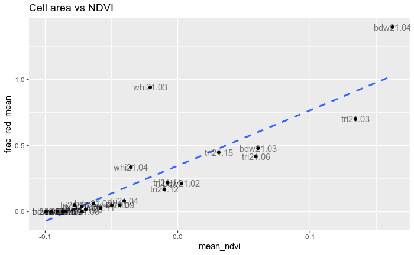

```r
my_plot <- function(df, y, x, title){
  y <- enquo(y)
  x <- enquo(x)
  df %>%
    ggplot(aes(y = !!y, x = !!x)) +
    geom_smooth(method = "lm", linetype = "dashed", se=FALSE) + #, formula = y~poly(x, 2)
    geom_point() +
    geom_text(aes(label = sample_id), alpha = 0.5) +
    ggtitle(title)
}
my_plot(joined, frac_red_mean, mean_ndvi, "Cell area vs NDVI")
```

```
Warning: Removed 3 rows containing non-finite values (stat_smooth).
Warning: Removed 3 rows containing missing values (geom_point).
Warning: Removed 3 rows containing missing values (geom_text).
```

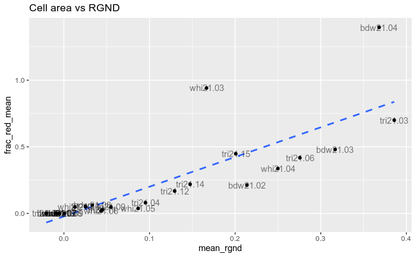

```r
my_plot(joined, frac_red_mean, mean_rgnd, "Cell area vs RGND")
```

```
Warning: Removed 4 rows containing non-finite values (stat_smooth).
Warning: Removed 4 rows containing missing values (geom_point).
Warning: Removed 4 rows containing missing values (geom_text).
```

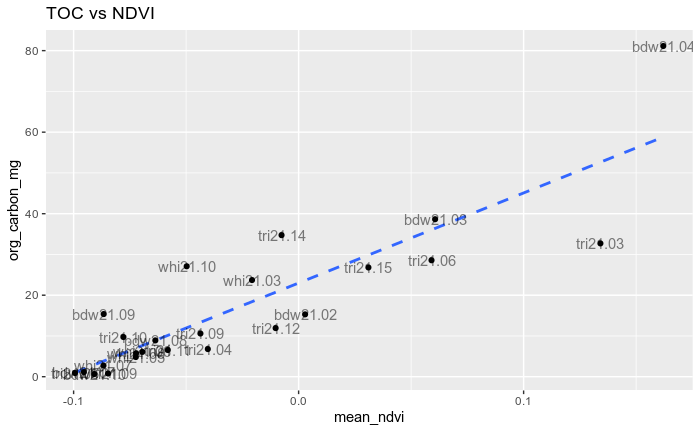

```r
my_plot(joined, org_carbon_mg, mean_ndvi, "TOC vs NDVI")
```

```
Warning: Removed 4 rows containing non-finite values (stat_smooth).
Warning: Removed 4 rows containing missing values (geom_point).
Warning: Removed 4 rows containing missing values (geom_text).
```

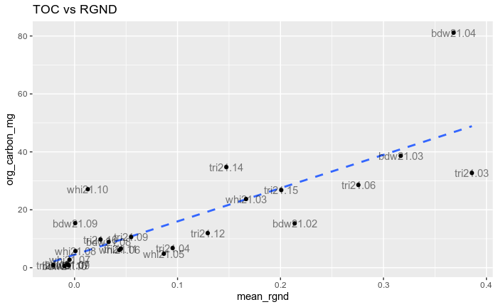

```r
my_plot(joined, org_carbon_mg, mean_rgnd, "TOC vs RGND")
```

NDVI looks like a tighter fit than RGND, makes sense since RGND will pick up on dust mixed in with the algae.

NDVI looks more linear, RGND more quadratic.

```
Warning: Removed 3 rows containing non-finite values (stat_smooth).
Warning: Removed 3 rows containing missing values (geom_point).
Warning: Removed 3 rows containing missing values (geom_text).
```

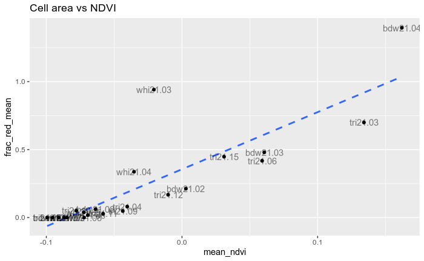

```r
joined_clean <- joined %>%
  filter(!(sample_id %in% c("bdw21.09", "whi21.10", "tri21.14"))) # dirty snow samples
my_plot(joined_clean, frac_red_mean, mean_ndvi, "Cell area vs NDVI")
```

```
Warning: Removed 3 rows containing non-finite values (stat_smooth).
Warning: Removed 3 rows containing missing values (geom_point).
Warning: Removed 3 rows containing missing values (geom_text).
```

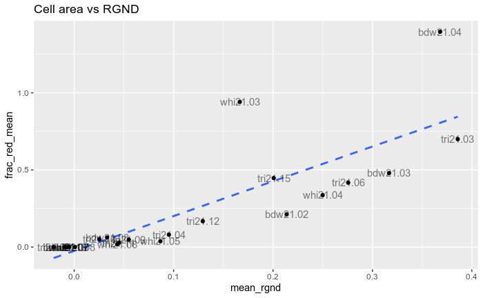

```r
my_plot(joined_clean, frac_red_mean, mean_rgnd, "Cell area vs RGND")
```

```
Warning: Removed 4 rows containing non-finite values (stat_smooth).
Warning: Removed 4 rows containing missing values (geom_point).
Warning: Removed 4 rows containing missing values (geom_text).
```

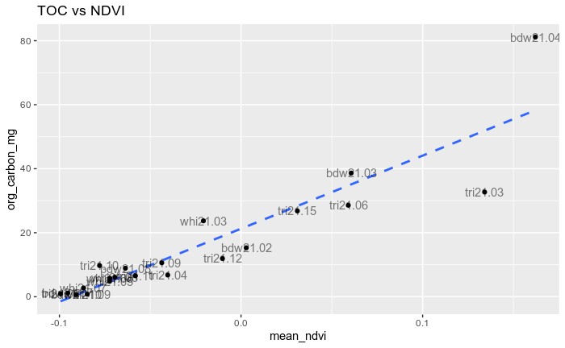

```r
my_plot(joined_clean, org_carbon_mg, mean_ndvi, "TOC vs NDVI")
```

```
Warning: Removed 4 rows containing non-finite values (stat_smooth).
Warning: Removed 4 rows containing missing values (geom_point).
Warning: Removed 4 rows containing missing values (geom_text).
```

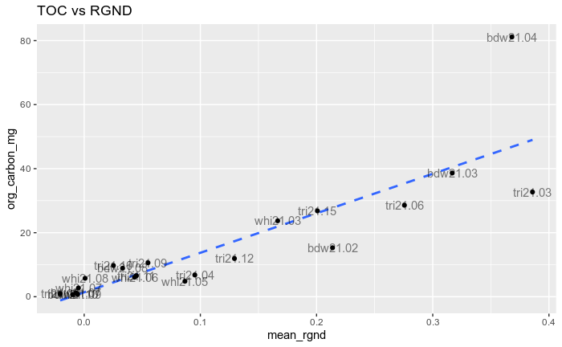

```r
my_plot(joined_clean, org_carbon_mg, mean_rgnd, "TOC vs RGND")
```

why is whi3 an outlier in cell area but not TOC?

## TOC vs algae

Compare the organic carbon content with the cell area, and cellcount

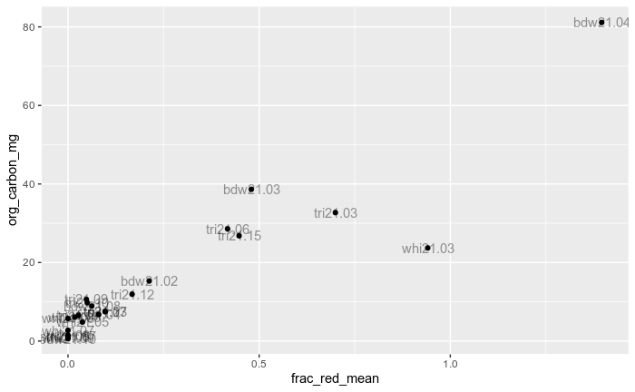

```r
joined_clean %>%
  ggplot(aes(y = org_carbon_mg, x = frac_red_mean)) +
  geom_point() +
  geom_text(aes(label = sample_id), alpha = 0.4)
```

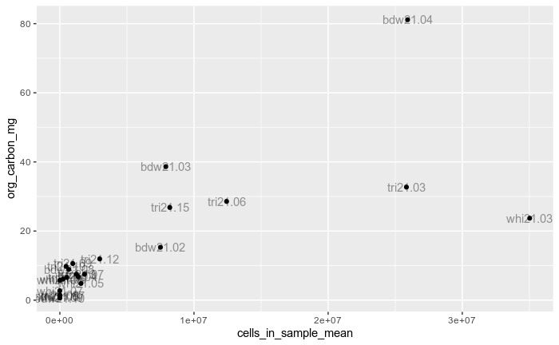

```r
joined_clean %>%
  ggplot(aes(y = org_carbon_mg, x = cells_in_sample_mean)) +
  geom_point() +
  geom_text(aes(label = sample_id), alpha = 0.4)
```

The two outliers

```r
joined_stats_clean %>%
  select(frac_red_mean, organic_carbon_mg_mean) %>%
  drop_na() %>%
  cor()
```

```
                       frac_red_mean organic_carbon_mg_mean
frac_red_mean              1.0000000              0.9260802
organic_carbon_mg_mean     0.9260802              1.0000000
```

Outliers tri3 and whi3 have less organic C per cell

# final algae abundance model

## plots

```r
# area
area_plot <- joined_stats_clean %>%
  ggplot(aes(y = frac_red_mean, x = ndvi_mean)) +
  geom_smooth(method = "lm", linetype = "dashed", se = FALSE) +
  geom_linerange(aes(ymin = frac_red_mean - frac_red_sd,
                      ymax = frac_red_mean + frac_red_sd),
                  alpha = 0.4) +
  geom_linerange(aes(xmin = ndvi_mean - ndvi_sd,
                     xmax = ndvi_mean + ndvi_sd),
                  alpha = 0.4) +
  geom_point(alpha = 0.4, size = 2) +
  geom_text(aes(label = sample_id), size = 3, alpha = 0.5, nudge_x = -0.01, data = joined_stats_clean %>% filter(frac_red_mean>0.5)) +
  theme_minimal() +
  labs(tag = "A") +
  labs(y = "Snow algae fractional area coverage") +
  theme(axis.title.x=element_blank(),
        axis.text.x=element_blank())
```

```r
toc_plot <- joined_stats_clean %>%
  ggplot(aes(y = organic_carbon_mg_mean, x = ndvi_mean)) +
  geom_smooth(method = "lm", linetype = "dashed", se = FALSE) +
  geom_linerange(aes(xmin = ndvi_mean - ndvi_sd,
                     xmax = ndvi_mean + ndvi_sd),
                  alpha = 0.4) +
  geom_point(alpha = 0.4, size = 2) +
  geom_text(aes(label = sample_id), size = 3, alpha = 0.5, nudge_x = -0.01, data = joined_stats_clean %>% filter(frac_red_mean>0.5)) +
  theme_minimal() +
  labs(tag = "B") +
  labs(y = "Total organic carbon (mg)", x = "NDVI")
```

```
Warning: Removed 1 rows containing non-finite values (stat_smooth).
Warning: Removed 1 rows containing missing values (geom_segment).
Warning: Removed 1 rows containing missing values (geom_segment).
Warning: Removed 1 rows containing missing values (geom_point).
Warning: Removed 2 rows containing non-finite values (stat_smooth).
Warning: Removed 2 rows containing missing values (geom_segment).
Warning: Removed 2 rows containing missing values (geom_point).
```

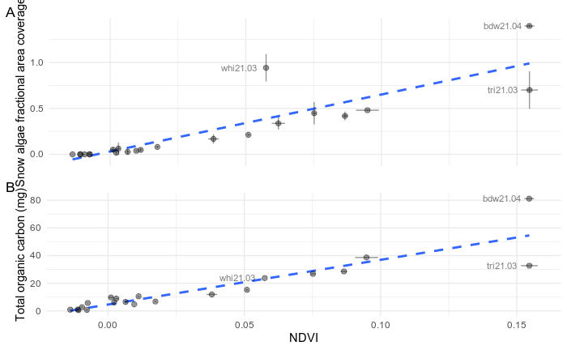

```r
grid.arrange(area_plot, toc_plot)
```

## NDVI linear

```r
toc_mod <- lm(organic_carbon_mg_mean ~ ndvi_mean, data = joined_stats_clean)
area_mod <- lm(frac_red_mean ~ ndvi_mean, data = joined_stats_clean)

toc_mod %>% tidy()
```

| term | estimate | std.error | statistic | p.value |
| --- | --- | --- | --- | --- |
| (Intercept) | 21.27216 | 1.814899 | 11.720853 | 3.851603e-10 |
| ndvi_mean | 228.44254 | 23.328233 | 9.792535 | 7.369433e-09 |

```r
area_mod %>% tidy()
```

| term | estimate | std.error | statistic | p.value |
| --- | --- | --- | --- | --- |
| (Intercept) | 0.3555974 | 0.04505288 | 7.892889 | 1.434627e-07 |
| ndvi_mean | 4.2040402 | 0.58983864 | 7.127441 | 6.615229e-07 |

## compare with RGND, polynomial models

```r
toc_mod_rgnd
```

[output not shown]

There are multivariate options that I chose to stay away from, see multivariate_algae_abund_models.R

# Albedo

Can we predict snow algae albedo from remote sensing data?

How does it compare to established ways of interpolating BB albedo from satellite bands?

# Planet

| sample_id | rgnd_mean | rgnd_sd | ndvi_mean | ndvi_sd |
| --- | --- | --- | --- | --- |
| bdw21.02 | 0.1548519271 | 7.374329e-04 | 0.04665158 | 3.538263e-04 |
| bdw21.03 | 0.2295333106 | 4.533344e-03 | 0.11778597 | 9.228058e-03 |
| bdw21.04 | 0.2709583508 | 5.881523e-03 | 0.21811571 | 3.816172e-03 |
| bdw21.06 | 0.0647921419 | 1.576049e-03 | -0.03188345 | 7.540023e-04 |
| bdw21.07 | -0.0010826871 | NA | -0.08792088 | NA |
| bdw21.08 | 0.0304869733 | 1.612087e-03 | -0.04835138 | 1.159906e-03 |
| bdw21.09 | 0.0056398177 | 4.858980e-04 | -0.07663953 | 4.701684e-05 |
| bdw21.10 | -0.0023968824 | 1.002598e-04 | -0.08288260 | 2.173054e-04 |
| tri21.03 | 0.2905473908 | 3.289096e-03 | 0.18874409 | 7.606127e-03 |
| tri21.04 | 0.0712657334 | 9.312810e-04 | -0.01501375 | 2.604518e-04 |

[output cut: 17 more lines]

```r
planet_joined <- joined_stats %>%
  select(-ndvi_mean:-rgnd_sd) %>% # swap S2 index vals with planet vals
  left_join(planet_nd)
```

[figure not shown]

```r
my_plot(planet_joined, frac_red_mean, ndvi_mean, "Cell area vs NDVI")
```

[figure not shown]

```r
my_plot(planet_joined, frac_red_mean, rgnd_mean, "Cell area vs RGND")
```

[figure not shown]

```r
my_plot(planet_joined, organic_carbon_mg_mean, ndvi_mean, "TOC vs NDVI")
```

[figure not shown]

```r
my_plot(planet_joined, organic_carbon_mg_mean, rgnd_mean, "TOC vs RGND")
```

Not quite as good a fit as with the more discreet Sentinel bands, but similar result.

# Pairs plot

```r
pairs_plot <- joined_stats_clean %>%
  select(-sample_id, -contains("_sd")) %>%
  rename_with(~str_remove(., "_mean")) %>% # shorten names for plotting
  rename_with(~str_remove(., "_mg")) %>%
  rename(total_n = nitrogen,
         inorg_c = inorganic_carbon,
         org_c = organic_carbon) %>%
  GGally::ggpairs()
pairs_plot
```

[output not shown]

### range

```r
joined_stats %>%
  summarise(min_rgnd = min(rgnd_mean),
            max_rgnd = max(rgnd_mean),
            min_albedo = min(albedo_mean),
            max_albedo = max(albedo_mean))
```

| min_rgnd | max_rgnd | min_albedo | max_albedo |
| --- | --- | --- | --- |
| -0.02068345 | 0.3860775 | 0.2624779 | 0.8349838 |

```r
joined_stats %>%
  arrange(-rgnd_mean)
```

| sample_id | ndvi_mean | ndvi_sd | rgnd_mean | rgnd_sd | albedo_mean | albedo_sd | frac_red_mean | frac_red_sd | inorganic_carbon_mg_mean | organic_carbon_mg_mean | nitrogen_mg_mean | cell_cm2_per_l_mean | cell_cm2_per_l_sd | cells_in_sample_mean | cells_in_sample_sd |
| --- | --- | --- | --- | --- | --- | --- | --- | --- | --- | --- | --- | --- | --- | --- | --- |
| tri21.03 | 0.134047845 | 5.740971e-03 | 0.3860775084 | 2.800644e-03 | 0.3347333 | 0.0030459456 | 0.69943027 | 0.204642113 | 0.017313734 | 32.7075965 | 1.02493748 | 4.2256250 | 1.23635031 | 25837500 | 6025515.2 |
| bdw21.04 | 0.162058598 | 2.352040e-03 | 0.3683180739 | 5.899169e-03 | 0.2624779 | 0.0009383027 | 1.39599496 | 0.012896049 | 0.007252127 | 81.1355609 | 1.76602506 | 11.7893750 | 0.10890896 | 25923750 | 1864147.2 |
| bdw21.03 | 0.060695582 | 6.950295e-03 | 0.3168827383 | 4.730619e-03 | 0.3710910 | 0.0182869770 | 0.47956567 | 0.004287624 | 0.006599183 | 38.6383538 | 0.80927205 | 4.7081250 | 0.04209365 | 7900000 | 320713.5 |
| tri21.06 | 0.058777937 | 7.303844e-04 | 0.2759018062 | 2.525445e-03 | 0.2681884 | 0.0016380882 | 0.41736394 | 0.047553814 | 0.014246414 | 28.5725176 | 0.88182769 | 3.6421875 | 0.41498532 | 12431250 | 1017902.3 |
| whi21.04 | -0.035316906 | 3.119463e-03 | 0.2500209362 | 2.327792e-03 | 0.3955441 | 0.0043538852 | 0.33661270 | 0.068721936 | NA | NA | NA | 3.5250000 | 0.71965443 | 7125000 | 1442653.8 |
| bdw21.02 | 0.002842036 | 1.482163e-04 | 0.2138815322 | 5.523132e-04 | 0.4926848 | 0.0065967853 | 0.21237238 | 0.004147255 | 0.001891898 | 15.2955278 | 0.33435749 | 1.3343750 | 0.02605797 | 7500000 | 2004459.3 |
| tri21.15 | 0.031113998 | 1.195395e-03 | 0.2008042842 | 2.052119e-03 | 0.3544694 | 0.0040218603 | 0.44752062 | 0.121406909 | 0.004638082 | 26.8074649 | 1.01616597 | 3.7793750 | 1.02529853 | 8195625 | 1823804.1 |
| whi21.03 | -0.020570872 | 0.000000e+00 | 0.1665354408 | 0.000000e+00 | 0.3793895 | 0.0000000000 | 0.94093994 | 0.148863815 | 0.004373156 | 23.7130469 | 0.58373508 | 6.1584375 | 0.97431139 | 35025000 | 3379718.9 |
| tri21.14 | -0.007375639 | 2.648998e-03 | 0.1473116669 | 3.996523e-03 | 0.2803909 | 0.0013402665 | 0.21864905 | 0.056128561 | 0.006170998 | 34.7339717 | 1.27705047 | 2.0203125 | 0.51862669 | 3878125 | 1215777.4 |
| tri21.12 | -0.010216535 | 1.846192e-03 | 0.1294525875 | 5.545423e-03 | 0.3673260 | 0.0106923353 | 0.16769560 | 0.050979029 | 0.010055100 | 11.9279361 | 0.42757900 | 1.3578125 | 0.41277150 | 2970625 | 738199.1 |

[output cut: 16 more lines]

## biomass per cell

```r
joined_stats %>%
  mutate(org_c_per_cell_ng = organic_carbon_mg_mean/cells_in_sample_mean * 1e6) %>% # mg to ng
  my_plot_var(org_c_per_cell_ng)
```

[output not shown]

## plots

```r
my_plot_crossbars <- function(dat, y_mean, y_sd, x_mean, x_sd, tag){
  x_mean <- enquo(x_mean)
  x_sd <- enquo(x_sd)
  y_mean <- enquo(y_mean)
  y_sd <- enquo(y_sd)

  dat %>%
    ggplot(aes(y = !!y_mean, x = !!x_mean)) +
    geom_pointrange(aes(ymin = !!y_mean - !!y_sd,
                        ymax = !!y_mean + !!y_sd),
                    alpha = 0.4) +
    geom_linerange(aes(xmin = !!x_mean - !!x_sd,
                       xmax = !!x_mean + !!x_sd),
                    alpha = 0.4) +
    theme_minimal() +
    labs(tag = tag)
}
# my_plot_crossbars(joined_stats, cells_per_ul_mean, cells_per_ul_sd, rgnd_mean, rgnd_sd) # test


outliers <- joined_stats %>%
  filter(sample_id %in% c("whi21.03", "bdw21.04"))

# A
p2a <- my_plot_crossbars(not_dirty, frac_red_mean, frac_red_sd, rgnd_mean, rgnd_sd, "A") +
  geom_smooth(method="lm", linetype = "dashed", formula = y ~ poly(x, 2),
              data = not_dirty %>% filter(!(sample_id %in% outliers$sample_id)) ) +
  labs(y = "Snow algae cell area") +
  theme(axis.title.x=element_blank(),
        axis.text.x=element_blank()) +
  geom_text(aes(label = sample_id), data = outliers, nudge_x = -0.03, size = 3)
p2a
```

[output not shown]

```r
# B
p2b <- my_plot_crossbars(not_dirty, organic_carbon_mg_mean, NA, rgnd_mean, rgnd_sd, "B") +
  geom_smooth(method="lm", linetype = "dashed", formula = y ~ poly(x, 2),
              data = not_dirty %>% filter(!(sample_id %in% outliers$sample_id)) ) +
  labs(y = "Total Organic Carbon (mg)", x = "RGND (field radiometer as S-2 band)") +
  geom_text(aes(label = sample_id), data = outliers, nudge_x = -0.03, size = 3)
p2b
```

[output not shown]

```r
grid.arrange(p2a, p2b, nrow = 2)
```

[output not shown]

```r
not_white <- not_dirty %>%
  filter(cells_per_ul_mean > 5) # white samples overestimate slope
p3a <- not_dirty %>%
  my_plot_crossbars(albedo_mean, albedo_sd, frac_red_mean, frac_red_sd, "A") +
  labs(y = "Broadband albedo", x = "Snow algae cell area") +
  geom_text(aes(label = sample_id), data = outliers, nudge_y = 0.02, size = 3) +
  geom_smooth(method="lm", linetype = "dashed", formula = y ~ log(x), data = not_white) # poly 2 results in a U-shaped curve
# including the 0s yields a sharp hockey-stick (also cant take log of 0)
p3a
```

[output not shown]

```r
p3b <- my_plot_crossbars(not_dirty, albedo_mean, albedo_sd, organic_carbon_mg_mean, NA, "B") +
  geom_smooth(method="lm", linetype = "dashed", formula = y ~ log(x)) +
  labs(y = "Broadband albedo", x = "Total Organic Carbon (mg)") +
  geom_text(aes(label = sample_id), data = outliers, nudge_y = 0.02, size = 3)
p3b
```

[output not shown]

```r
lm(albedo_mean~organic_carbon_mg_mean, data=not_dirty) %>% summary()
```

[output not shown]

```r
p3c <- my_plot_crossbars(not_white, albedo_mean, albedo_sd, rgnd_mean, rgnd_sd, "C") +
  geom_smooth(method="lm", linetype = "dashed", formula = y ~ x) +
  labs(y = "Broadband albedo", x = "RGND") +
  geom_text(aes(label = sample_id), data = outliers, nudge_y = 0.02, size = 3)
p3c
```

[output not shown]

```r
lm(albedo_mean~rgnd_mean, data=not_white) %>% summary()
not_white %>%
  select(albedo_mean, rgnd_mean) %>%
  cor()
```

[output not shown]

```r
grid.arrange(p3a, p3b, p3c, nrow = 3)
```

[output not shown]

```r
joined_stats %>%
  filter(!(sample_id %in% dirty_samples)) %>%
  ggplot(aes(y = albedo_mean, x = rgnd_mean)) +
  geom_pointrange(aes(ymin = albedo_mean - albedo_sd,
                      ymax = albedo_mean + albedo_sd),
                  alpha = 0.4) +
  geom_linerange(aes(xmin = rgnd_mean - rgnd_sd,
                     xmax = rgnd_mean + rgnd_sd),
                  alpha = 0.4) +
  geom_smooth(method = "lm")+
  theme_minimal()
```

[output not shown]

Direct comparison of albedo and cell abundance indicators

```r
joined_stats %>%
  filter(!(sample_id %in% dirty_samples)) %>% #remove mineral dust samples
  ggplot(aes(y = albedo_mean, x = frac_red_mean)) +
  geom_pointrange(aes(ymin = albedo_mean - albedo_sd,
                      ymax = albedo_mean + albedo_sd),
                  alpha = 0.4) +
  geom_linerange(aes(xmin = frac_red_mean - frac_red_sd,
                     xmax = frac_red_mean + frac_red_sd),
                  alpha = 0.4) +
  theme_minimal() +
  geom_smooth(method="lm", linetype = "dashed", se=FALSE, formula = y ~ x)
  # geom_text(aes(label = sample_id))
```

[output not shown]

```r
joined_stats %>%
  filter(!(sample_id %in% dirty_samples)) %>% #remove mineral dust samples
  # filter(!(sample_id %in% outliers$sample_id)) %>%  # remove outliers
  ggplot(aes(y = albedo_mean, x = organic_carbon_mg_mean)) +
  geom_pointrange(aes(ymin = albedo_mean - albedo_sd,
                      ymax = albedo_mean + albedo_sd),
                  alpha = 0.4) +
  theme_minimal() +
  geom_smooth(method="lm", linetype = "dashed", se=FALSE, formula = y ~ x) #+
  # geom_text(aes(label = sample_id))
```

[output not shown]

```r
joined_stats$albedo_mean %>% range()
```

[output not shown]

# Models

cell count

```r
count_mod <- lm(cells_per_ul_mean ~ rgnd_mean, data=joined_stats)
summary(count_mod)
```

[output not shown]

cell area

```r
area_mod <- lm(frac_red_mean ~ rgnd_mean, data=joined_stats)
summary(area_mod)
```

[output not shown]

```r
toc_mod <- lm(organic_carbon_mg_mean ~ rgnd_mean, data=joined_stats)
tidy(toc_mod)
```

[output not shown]

```r
nitrogen_mod <- lm(nitrogen_mg_mean ~ rgnd_mean, data=joined_stats)
tidy(nitrogen_mod)
```

[output not shown]

albedo ~ RGND

```r
albedo_rgnd_mod <- lm(albedo_mean ~ rgnd_mean, data=joined_stats)
tidy(albedo_rgnd_mod)
```

[output not shown]

albedo ~ cell area

```r
albedo_area_mod <- lm(albedo_mean ~ frac_red_mean, data=joined_stats)
tidy(albedo_area_mod)
```

[output not shown]

albedo ~ organic carbon

```r
albedo_carbon_mod <- lm(albedo_mean ~ organic_carbon_mg_mean, data=joined_stats)
tidy(albedo_carbon_mod)
```

[output not shown]

Present models in table

```r
get_formula <- function(mod){
  call <- mod$call %>% as.character()
  call[2]
}

tidy(area_mod) %>% add_column(formula = get_formula(area_mod), .before=1)

make_entry <- function(mod){
  tidy(mod) %>%
    add_column(formula = get_formula(mod), .before=1)
}
mod_results <- bind_rows(
  make_entry(area_mod),
  make_entry(toc_mod),
  make_entry(nitrogen_mod),
  make_entry(albedo_rgnd_mod),
  make_entry(albedo_area_mod),
  make_entry(albedo_carbon_mod)
)
mod_results %>%
  kbl(caption = "Model results") %>%
  kable_classic(full_width = FALSE, html_font = "Cambria")
```

[output not shown]